# Exploratory Data Analysis

Opioid overdose emergency department visits and opioid overdose deaths in Virginia counties.

Faysal Shaikh

Last updated April 04, 2024

This document contains exploratory data analysis on opioid overdose data sources (emergency department visits and overdose deaths) to-be used in my thesis project. I have included relevant package imports in the chunk below:

```r
library(tidyverse)
library(readxl)
library(sf)
library(broom)
# library(stringr)
# library(forecast)
```

# Data Sources

As of now, we are using 2 types of data sources for outcomes data:

- Opioid overdose emergency department (ED) visits
- Opioid overdose deaths

We also include geographic data in a shapefile of 2023 Virginia Administrative Boundaries [obtained from the Virginia Geographic Information Network site](https://vgin.vdem.virginia.gov/datasets/777890ecdb634d18a02eec604db522c6/about) for later use in exploratory chloropleth mapping.

We handle project directory and data source filepath specification immediately below, before performing data exploration on our 2 major data sources separately in the proceeding sections. Notably, we also handle data source filepath specification for the aforementioned geographic data.

```r
# path specification: data directory
data_dir_path <- # uncomment appropriate option below
    # "d:/Codebase/ms-thesis/data/" # laptop
    "f:/Codebase/ms-thesis/data/" # desktop

# filename specification: overdose ED visits
vdh_ed_visits_fname <-
    "Drug-Overdose-ED-Visits_Virginia-January-2024.xlsx"

# filename specification: overdose deaths
cdc_wonder_overdose_deaths_99_20_fname <-
    "cdc-wonder_final-mcd_1999-2020.tsv" # 1999-2020 final
cdc_overdose_deaths_18_21_fname <-
    "cdc-wonder_final-mcd_2018-2021.tsv" # 2018-2021 final

# filename specification: Virginia administrative boundaries shapefiles
va_admin_bound <-
    "VirginiaAdministrativeBoundary.shp/VirginiaCounty.shp"
```

## Geography: Virginia Counties

This project examines data on Virginia counties as the primary units of analysis. As a geographic reference, we include below a labeled map of Virginia counties obtained from [the Virginia Association of Counties (VACO) website](https://www.vaco.org/about/regions/):

[figure not shown]

Similarly, we generate our own map of Virginia counties and county-equivalents via the previously mentioned 2023 Virginia Administrative Boundaries shapefile, visualized without additional data below:

```r
va_counties <- # read shapefile
    st_read(paste0(data_dir_path, va_admin_bound)) %>%
    mutate(NAMELSAD = str_to_upper(NAMELSAD)) # uppercase names to avoid
```

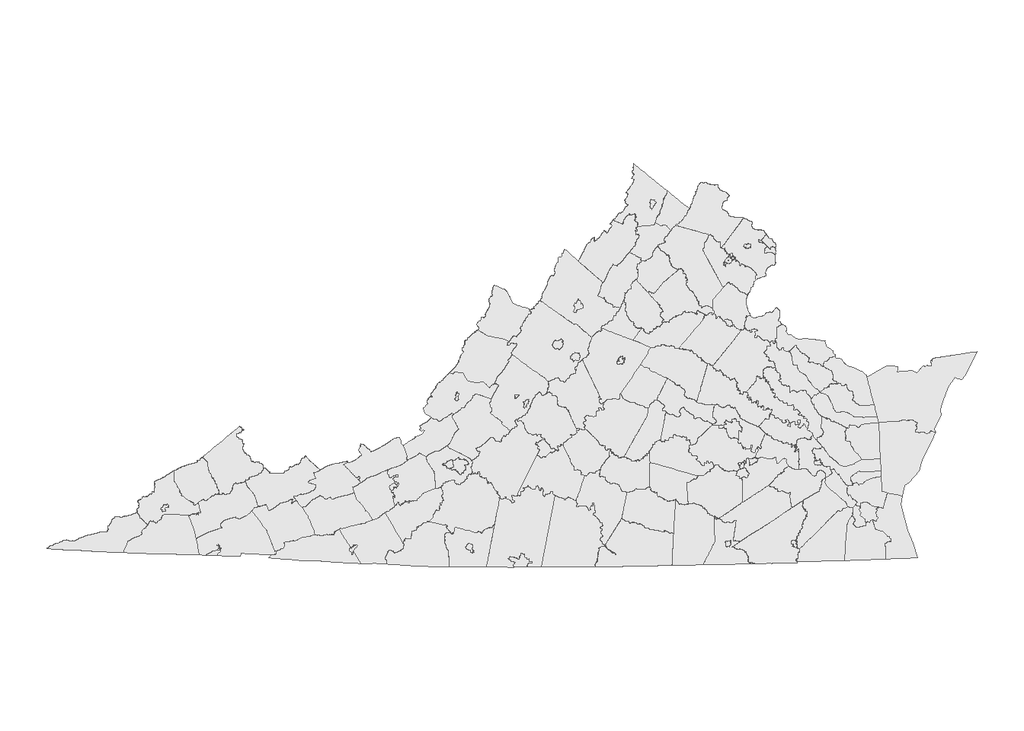

```r
                                              # capitalization merge conflicts

# plot geographic data
va_counties %>%
    ggplot() +
    geom_sf() +
    theme_void()
```

We will use this template as the basis for chloropleth exploratory data visualizations throughout this process.

## ED Visits

We utilize the Virginia Department of Health website to download data on unintentional drug overdose from the [syndromic surveillance webpage](https://www.vdh.virginia.gov/surveillance-and-investigation/syndromic-surveillance/drug-overdose-surveillance/). Data are in the form of a Microsoft Excel workbook and are loaded-in via the below chunk:

```r
# preparation for reading-in data: VDH opioid overdose ED visits
vdh_ed_visits_fullpath <-
    paste0(data_dir_path, vdh_ed_visits_fname) # precombine fname parts
vdh_ed_visits_sheetslist <-
    excel_sheets(vdh_ed_visits_fullpath) # get list of worksheet "tabs" for MS
                                         # Excel workbook file to mask for
                                         # specific sheet(s)

# reading-in data: VDH opioid overdose ED visits
vdh_ed_visits_nonheroin_opioid <- read_excel(
    path = vdh_ed_visits_fullpath,
    sheet = vdh_ed_visits_sheetslist[5] # locality opioid
)
vdh_ed_visits_heroin <- read_excel(
    path = vdh_ed_visits_fullpath,
    sheet = vdh_ed_visits_sheetslist[6] # locality heroin
)

## output data: nonheroin opioid ED visits
dates_vec <- # derived years date-vector for time masking (as-needed)
    2015:2023 %>%
    paste("Total") # Year "Total"

vdh_localities_df <- # derived data frame for geographic masking (as-needed)
    vdh_ed_visits_nonheroin_opioid["OPIOID"][-1, ] %>%
    rename("Locality" = "OPIOID") %>%
    lapply(
        function(x) str_replace_all(x, "[^a-zA-Z0-9 ]", "") # remove special
                                                            # characters (i.e.,
                                                            # double-dagger)
    ) %>%
    as.data.frame() %>%
    mutate(Locality = str_to_upper(Locality)) # avoid name case issues for merge

nonheroin_wide <- # nonheroin opioid ED visits (wide format)
    vdh_localities_df %>%
    cbind(vdh_ed_visits_nonheroin_opioid[dates_vec][-1, ]) %>%
    mutate(across(-Locality, as.numeric)) # convert non-labels to numeric

nonheroin_tslist <- # nonheroin opioid ED visit ts objects stored in named list
    sapply(
        vdh_localities_df[, ],
        function(x) {
            nonheroin_wide[nonheroin_wide["Locality"] == x][2:110] %>%
                as.numeric() %>%
                ts(start = 2015, end = 2023, frequency = 1) # ensure this is
                                                            # updated to match
                                                            # the data timeframe
        },
        simplify = FALSE, USE.NAMES = TRUE
    )

nonheroin_opioid_edvisits_df <-
    nonheroin_wide %>%
    pivot_longer(
        cols = dates_vec,
        names_to = "Year", # ensure this is updated to match the data timeframe
        values_to = "Count: Nonheroin Opioid ED Visits"
    ) %>%
    mutate(`Count: Nonheroin Opioid ED Visits` =
        as.numeric(`Count: Nonheroin Opioid ED Visits`)
    )

## output data: heroin (opioid) ED visits
heroin_wide <- # heroin ED visits (wide format)
    vdh_localities_df %>%
    cbind(vdh_ed_visits_heroin[dates_vec][-1, ]) %>%
    mutate(across(-Locality, as.numeric)) # convert non-labels to numeric

heroin_edvisits_ts_list <- # heroin ED visit ts objects stored in named list
    sapply(
        vdh_localities_df[, ],
        function(x) {
            heroin_wide[heroin_wide["Locality"] == x][2:110] %>%
            as.numeric() %>%
            ts(start = 2015, end = 2023, frequency = 1)
        }, # ensure this is updated to the data
    simplify = FALSE, USE.NAMES = TRUE
    )

heroin_edvisits_df <-
    heroin_wide %>%
    pivot_longer(
        cols = dates_vec,
        names_to = "Year", # ensure this is updated to match the data timeframe
        values_to = "Count: Heroin ED Visits"
    ) %>%
    mutate(`Count: Heroin ED Visits` =
        as.numeric(`Count: Heroin ED Visits`)
    )

## output data: combined ED visits [heroin (opioid) + nonheroin opioid]
combined_edvisits_df <-
    inner_join(heroin_edvisits_df, nonheroin_opioid_edvisits_df) %>%
    group_by(Locality, Year) %>%
    rename(
        heroin = `Count: Heroin ED Visits`,
        nonheroin_opioid = `Count: Nonheroin Opioid ED Visits`
    ) %>%
    mutate(
        Year = as.numeric(str_sub(Year, end = -6)), # ensure this is updated to
                                                    # match the data timeframe
        combined = sum(c(heroin, nonheroin_opioid)),
    )

# print data in wide format as an HTML table
bind_rows(
    nonheroin_wide,
    heroin_wide
) %>%
    group_by(Locality) %>%
    summarize_all(sum) %>%
    knitr::kable(style = "html")
```

| Locality | 2015 Total | 2016 Total | 2017 Total | 2018 Total | 2019 Total | 2020 Total | 2021 Total | 2022 Total | 2023 Total |
| --- | --- | --- | --- | --- | --- | --- | --- | --- | --- |
| ACCOMACK COUNTY | 19 | 23 | 19 | 3 | 25 | 18 | 37 | 40 | 47 |
| ALBEMARLE COUNTY | 197 | 163 | 186 | 154 | 166 | 136 | 155 | 198 | 222 |
| ALEXANDRIA CITY | 101 | 108 | 132 | 96 | 84 | 116 | 112 | 104 | 113 |
| ALLEGHANY COUNTY | 30 | 35 | 27 | 17 | 26 | 42 | 38 | 44 | 38 |
| AMELIA COUNTY | 13 | 7 | 26 | 16 | 14 | 21 | 20 | 15 | 6 |
| AMHERST COUNTY | 23 | 26 | 25 | 23 | 28 | 38 | 52 | 63 | 67 |
| APPOMATTOX COUNTY | 21 | 17 | 7 | 13 | 12 | 11 | 37 | 17 | 25 |
| ARLINGTON COUNTY | 112 | 154 | 134 | 102 | 102 | 104 | 124 | 133 | 121 |
| AUGUSTA COUNTY | 13 | 16 | 110 | 177 | 165 | 163 | 176 | 195 | 165 |
| BATH COUNTY | 3 | 0 | 4 | 5 | 7 | 3 | 3 | 9 | 7 |
| BEDFORD COUNTY | 52 | 71 | 87 | 94 | 76 | 84 | 109 | 109 | 84 |
| BLAND COUNTY | 0 | 1 | 1 | 6 | 6 | 8 | 16 | 15 | 13 |
| BOTETOURT COUNTY | 22 | 33 | 36 | 30 | 42 | 56 | 59 | 50 | 40 |
| BRISTOL CITY | 69 | 44 | 54 | 51 | 44 | 47 | 39 | 67 | 61 |
| BRUNSWICK COUNTY | 12 | 13 | 20 | 13 | 20 | 17 | 37 | 77 | 23 |
| BUCHANAN COUNTY | 31 | 35 | 20 | 23 | 22 | 38 | 44 | 58 | 57 |
| BUCKINGHAM COUNTY | 15 | 14 | 14 | 15 | 21 | 20 | 25 | 33 | 26 |
| BUENA VISTA CITY | 26 | 30 | 34 | 43 | 33 | 43 | 47 | 59 | 46 |
| CAMPBELL COUNTY | 24 | 37 | 25 | 28 | 26 | 40 | 44 | 43 | 50 |
| CAROLINE COUNTY | 43 | 52 | 53 | 40 | 35 | 72 | 55 | 51 | 38 |
| CARROLL COUNTY | 22 | 21 | 35 | 45 | 27 | 33 | 23 | 63 | 55 |
| CHARLES CITY COUNTY | 3 | 11 | 6 | 6 | 2 | 7 | 6 | 6 | 3 |
| CHARLOTTE COUNTY | 11 | 15 | 15 | 21 | 17 | 15 | 20 | 29 | 26 |
| CHARLOTTESVILLE CITY | 197 | 163 | 186 | 154 | 166 | 136 | 155 | 198 | 222 |
| CHESAPEAKE CITY | 270 | 353 | 349 | 281 | 284 | 426 | 368 | 416 | 381 |
| CHESTERFIELD COUNTY | 387 | 442 | 510 | 449 | 478 | 609 | 682 | 544 | 470 |
| CLARKE COUNTY | 13 | 12 | 17 | 7 | 14 | 17 | 9 | 5 | 15 |
| COLONIAL HEIGHTS CITY | 387 | 442 | 510 | 449 | 478 | 609 | 682 | 544 | 470 |
| COVINGTON CITY | 30 | 35 | 27 | 17 | 26 | 42 | 38 | 44 | 38 |
| CRAIG COUNTY | 4 | 5 | 12 | 6 | 10 | 8 | 6 | 7 | 4 |

[output cut: 104 more lines]

According to VDH criteria, [opioid data seems to exclude “heroin”](https://www.vdh.virginia.gov/surveillance-and-investigation/syndromic-surveillance/drug-overdose-case-definition/#:~:text=medication%20or%20drug%2C-,heroin,-%2C%20dope%2C%20speed%20ball) ICD codes. Experts believe heroin opioid overdose deaths have plateaued in the wake of the latest wave(s) of the opioid epidemic, driven now heavily by synthetic opioids such as fentanyl. We therefore visualize heroin ED visits in a dedicated section to verify this.

## Overdose Deaths

```r
# preparation for reading-in data: CDC WONDER opioid overdose deaths
cdc_wonder_overdose_deaths_99_20_fullpath <-
    paste0(data_dir_path, cdc_wonder_overdose_deaths_99_20_fname)
cdc_overdose_deaths_18_21_fullpath <-
    paste0(data_dir_path, cdc_overdose_deaths_18_21_fname)

# reading-in data: CDC WONDER opioid overdose deaths
cdc_wonder_overdose_deaths_99_20_df <- # 1999-2020 data
    read_tsv(
        cdc_wonder_overdose_deaths_99_20_fullpath, # already in long format
        col_select = c("County", "Year", "Deaths", "Population")) %>%
    drop_na() %>%
    mutate(Deaths = as.numeric(Deaths)) %>%
    mutate(County = str_sub(str_to_upper(County), end = -5)) # avoid name case
                                                             # issues for merge

cdc_wonder_overdose_deaths_20_21_df <- # 2018-2021 data
    read_tsv(
        cdc_overdose_deaths_18_21_fullpath, # already in long format
        col_select = c("County", "Year", "Deaths", "Population")) %>%
    drop_na() %>%
    mutate(Deaths = as.numeric(Deaths)) %>%
    mutate(County = str_sub(str_to_upper(County), end = -5)) %>%
    filter(Year > 2020) # remove overlap from 1999-2020 data
```

```r
# data preprocessing: CDC WONDER opioid overdose deaths
cdc_wonder_overdose_deaths_df <- rbind( # data merge: 1999-2020 + 2018-2021
    cdc_wonder_overdose_deaths_99_20_df, # 1999-2020 data
    cdc_wonder_overdose_deaths_20_21_df # 2018-2021 data
)

cdc_localities_df <- # derived data frame for geographic masking (as-needed)
    cdc_wonder_overdose_deaths_df[, 1] %>%
    unique() %>%
    as.data.frame()

overdose_deaths_wide <- # opioid overdose deaths (wide format)
    cdc_wonder_overdose_deaths_df %>%
    select(c(County, Year, Deaths)) %>%
    group_by(County) %>%
    pivot_wider(names_from = Year, values_from = Deaths)

overdose_deaths_tslist <- # overdose death ts objects stored in named list
    sapply(
    cdc_localities_df[, ],
    function(x) {
        overdose_deaths_wide[overdose_deaths_wide["County"] == x, ] %>%
        as.numeric() %>%
        ts(start = 1999, end = 2020) # ensure this is updated to the data
    },
    simplify = FALSE,
    USE.NAMES = TRUE
    )

# print data in wide format as an HTML table
overdose_deaths_wide %>%
    knitr::kable(style = "html")
```

| County | 1999 | 2000 | 2001 | 2002 | 2003 | 2004 | 2005 | 2006 | 2007 | 2008 | 2009 | 2010 | 2011 | 2012 | 2013 | 2014 | 2015 | 2016 | 2017 | 2018 | 2019 | 2020 | 2021 |
| --- | --- | --- | --- | --- | --- | --- | --- | --- | --- | --- | --- | --- | --- | --- | --- | --- | --- | --- | --- | --- | --- | --- | --- |
| ACCOMACK COUNTY | NA | NA | NA | NA | NA | NA | NA | NA | NA | 0 | NA | NA | NA | NA | NA | NA | NA | NA | NA | NA | NA | NA | NA |
| ALBEMARLE COUNTY | NA | NA | 0 | NA | 0 | NA | NA | NA | NA | NA | NA | NA | NA | NA | NA | NA | NA | NA | NA | NA | NA | 10 | 14 |
| ALLEGHANY COUNTY | 0 | NA | 0 | NA | NA | 0 | NA | NA | NA | 0 | 0 | NA | 0 | NA | 0 | NA | NA | NA | NA | NA | NA | NA | NA |
| AMELIA COUNTY | NA | NA | NA | 0 | 0 | 0 | 0 | 0 | 0 | 0 | NA | 0 | 0 | 0 | 0 | NA | NA | NA | NA | NA | NA | NA | NA |
| AMHERST COUNTY | 0 | 0 | NA | NA | NA | NA | NA | NA | NA | NA | 0 | NA | NA | NA | 0 | NA | 0 | NA | NA | 0 | NA | NA | 11 |
| APPOMATTOX COUNTY | 0 | 0 | 0 | 0 | 0 | 0 | 0 | 0 | 0 | 0 | 0 | 0 | 0 | 0 | NA | NA | NA | NA | 0 | NA | NA | NA | NA |
| ARLINGTON COUNTY | NA | NA | NA | NA | NA | NA | NA | NA | NA | 10 | NA | NA | NA | NA | NA | NA | 17 | 21 | 16 | NA | 12 | 26 | 25 |
| AUGUSTA COUNTY | NA | NA | NA | NA | NA | NA | NA | NA | NA | NA | 14 | NA | NA | NA | NA | NA | NA | NA | 12 | NA | NA | NA | NA |
| BATH COUNTY | 0 | 0 | 0 | 0 | 0 | 0 | 0 | NA | 0 | 0 | 0 | 0 | 0 | NA | 0 | 0 | 0 | 0 | 0 | NA | 0 | 0 | 0 |
| BEDFORD COUNTY | 0 | NA | NA | NA | NA | NA | NA | NA | NA | NA | NA | 10 | NA | NA | NA | NA | NA | NA | 12 | NA | NA | 11 | 19 |
| BLAND COUNTY | 0 | 0 | NA | 0 | NA | NA | NA | 0 | 0 | NA | NA | NA | NA | 0 | NA | NA | NA | NA | NA | 0 | 0 | NA | 0 |
| BOTETOURT COUNTY | 0 | NA | NA | NA | 0 | NA | NA | NA | 0 | NA | NA | NA | NA | NA | NA | NA | NA | NA | NA | NA | NA | NA | 10 |
| BRUNSWICK COUNTY | 0 | NA | 0 | 0 | 0 | 0 | NA | 0 | 0 | 0 | 0 | 0 | 0 | 0 | 0 | 0 | NA | NA | NA | NA | NA | NA | NA |
| BUCHANAN COUNTY | NA | NA | NA | NA | NA | NA | 10 | NA | NA | 11 | NA | NA | NA | 13 | NA | NA | NA | NA | NA | NA | NA | NA | NA |
| BUCKINGHAM COUNTY | 0 | NA | NA | NA | 0 | NA | 0 | 0 | NA | 0 | 0 | 0 | 0 | 0 | NA | 0 | 0 | 0 | NA | 0 | 0 | NA | NA |
| CAMPBELL COUNTY | 0 | 0 | 0 | 0 | NA | NA | NA | NA | NA | NA | NA | NA | NA | NA | NA | NA | NA | NA | NA | NA | NA | 11 | NA |
| CAROLINE COUNTY | NA | 0 | NA | NA | 0 | 0 | 0 | NA | NA | NA | NA | 0 | NA | NA | NA | NA | NA | 10 | NA | 11 | NA | 12 | 18 |
| CARROLL COUNTY | NA | 0 | NA | NA | NA | NA | NA | NA | NA | NA | NA | NA | NA | NA | 0 | NA | NA | NA | NA | NA | NA | NA | NA |
| CHARLES CITY COUNTY | 0 | 0 | 0 | 0 | 0 | 0 | NA | 0 | 0 | NA | 0 | 0 | NA | 0 | NA | 0 | NA | NA | NA | NA | NA | 0 | NA |
| CHARLOTTE COUNTY | 0 | 0 | 0 | 0 | 0 | NA | 0 | 0 | 0 | NA | NA | NA | 0 | NA | NA | 0 | 0 | NA | NA | NA | NA | NA | NA |
| CHESTERFIELD COUNTY | NA | 13 | 11 | 10 | 11 | 11 | 10 | 12 | 13 | 28 | 17 | 15 | 22 | 18 | 27 | 22 | 27 | 64 | 65 | 84 | 76 | 106 | 117 |
| CLARKE COUNTY | 0 | 0 | 0 | NA | 0 | 0 | NA | 0 | NA | 0 | 0 | 0 | NA | NA | 0 | NA | NA | NA | NA | NA | NA | 0 | NA |
| CRAIG COUNTY | 0 | 0 | NA | NA | NA | 0 | NA | 0 | 0 | NA | NA | NA | 0 | 0 | 0 | 0 | 0 | NA | 0 | 0 | 0 | NA | NA |
| CULPEPER COUNTY | 0 | NA | 0 | NA | NA | NA | NA | 0 | NA | NA | NA | NA | NA | NA | 13 | 12 | 12 | 12 | 22 | 13 | 10 | 17 | 21 |
| CUMBERLAND COUNTY | 0 | 0 | 0 | 0 | 0 | 0 | NA | NA | NA | 0 | 0 | 0 | 0 | NA | NA | 0 | NA | NA | NA | 0 | NA | NA | NA |
| DICKENSON COUNTY | 0 | NA | NA | NA | NA | NA | NA | NA | 10 | NA | NA | NA | 10 | NA | NA | NA | NA | NA | NA | NA | NA | NA | NA |
| DINWIDDIE COUNTY | 0 | 0 | NA | 0 | NA | 0 | 0 | 0 | 0 | NA | 0 | NA | NA | NA | NA | NA | NA | 0 | NA | NA | NA | NA | NA |
| ESSEX COUNTY | 0 | 0 | 0 | 0 | 0 | 0 | 0 | NA | 0 | 0 | NA | NA | 0 | 0 | NA | 0 | 0 | NA | 0 | NA | 0 | NA | NA |
| FAIRFAX COUNTY | 18 | 11 | 25 | 27 | 19 | 14 | 23 | 27 | 45 | 35 | 27 | 23 | 33 | 40 | 40 | 58 | 65 | 85 | 109 | 80 | 82 | 91 | 100 |
| FAUQUIER COUNTY | NA | 0 | NA | NA | NA | NA | NA | NA | 10 | NA | NA | NA | 12 | NA | NA | NA | 12 | 23 | 16 | 15 | 17 | NA | 18 |

[output cut: 105 more lines]

I have downloaded 3 different versions of CDC WONDER data:

- bridged-race final multiple causes of death (1999-2020),
- single-race final multiple cause of death (2018-2021), and
- provisional cause of death (2018-feb2024).

Data utilized apropriate ICD10 codes for underlying cause of death as drug overdose and multiple causes of death codes involving opioid drugs, as specified by the [KFF](https://www.kff.org/other/state-indicator/opioid-overdose-death-rates/?currentTimeframe=0&sortModel=%7B%22colId%22:%22Location%22,%22sort%22:%22asc%22%7D) and a [SAMHSA resource document](https://mnprc.org/wp-content/uploads/2019/01/using-icd-10-codes-to-assess-opioid-related-overdose-deaths.pdf).

# Data Missingness

Below tibbles show the data “fullness” (non-missingness). We may choose to select Counties for inclusion based on their data availability. We choose to look at both non-NA as well as {non-NA AND nonzero} non-missingness, since a County with a low population may alternate between zero and missing values based on data suppression.

## ED Visits

```r
combined_edvisits_df %>%
    group_by(Locality) %>%
    summarize(
        nonNA_combined_edvisits =
            sum(!is.na(combined)),
        nonzero_nonNA_combined_edvisits =
            sum(!is.na(combined) & (combined != 0))
    ) %>%
    arrange(desc(nonzero_nonNA_combined_edvisits)) %>% # sort descending by
                                                       # nonzero & nonNA values
    print(n = 135) # print all 135 counties
```

```
## # A tibble: 134 x 3
##     Locality              nonNA_combined_edvisits nonzero_nonNA_combined_edvis~1
##     <chr>                                   <int>                          <int>
##   1 ACCOMACK COUNTY                             9                              9
##   2 ALBEMARLE COUNTY                            9                              9
##   3 ALEXANDRIA CITY                             9                              9
##   4 ALLEGHANY COUNTY                            9                              9
##   5 AMELIA COUNTY                               9                              9
##   6 AMHERST COUNTY                              9                              9
##   7 APPOMATTOX COUNTY                           9                              9
##   8 ARLINGTON COUNTY                            9                              9
##   9 AUGUSTA COUNTY                              9                              9
##  10 BEDFORD COUNTY                              9                              9
##  11 BOTETOURT COUNTY                            9                              9
##  12 BRISTOL CITY                                9                              9
```

[output cut: 123 more lines]

## Overdose Deaths

```r
cdc_wonder_overdose_deaths_df %>%
    mutate(Deaths = as.numeric(Deaths)) %>%
    group_by(County) %>%
    summarize(
        nonNA_deaths =
            sum(!is.na(Deaths)),
        nonzero_nonNA_deaths =
            sum(!is.na(Deaths) & (Deaths != 0))
    ) %>%
    arrange(desc(nonzero_nonNA_deaths)) %>% # sort descending by nonzero & nonNA
                                            # values
    print(n = 135) # print all 135 counties
```

```
## # A tibble: 135 x 3
##     County                nonNA_deaths nonzero_nonNA_deaths
##     <chr>                        <int>                <int>
##   1 FAIRFAX COUNTY                  23                   23
##   2 RICHMOND CITY                   23                   23
##   3 VIRGINIA BEACH CITY             23                   23
##   4 CHESTERFIELD COUNTY             22                   22
##   5 HENRICO COUNTY                  22                   22
##   6 PRINCE WILLIAM COUNTY           20                   20
##   7 CHESAPEAKE CITY                 19                   19
##   8 NORFOLK CITY                    19                   19
##   9 ROANOKE CITY                    16                   16
##  10 NEWPORT NEWS CITY               14                   14
##  11 TAZEWELL COUNTY                 14                   14
##  12 PORTSMOUTH CITY                 13                   13
```

[output cut: 123 more lines]

# Exploratory Data Visualization

We are interested in exploring a few different types of data visualizations for our trajectories of opioid overdose emergency department visits and deaths. Namely, we are interested in exploring:

We prespecify our desired Counties/Cities for #3 immediately below:

```r
chosen_areas <- c("ALEXANDRIA CITY", "FAIRFAX COUNTY", "FAIRFAX CITY")
```

## ED Visits

### Combined opioids (incl. heroin)

```r
# generic plotting function for combined opioid ED visits
combined_edvisits_plotter <- function(locality) {
    combined_edvisits_df %>%
    filter(Locality == locality) %>%
    ggplot(aes(x = Year, y = combined, group = Locality)) +
        geom_line() +
        geom_point() +
        theme_classic() +
        theme(legend.position = "none") +
        ggtitle(paste0(locality, ": OPIOID ED VISITS")) +
        ylab("Count: Combined Opioid (incl. Heroin) ED Visits")
}
# plot Virginia state overall
combined_edvisits_plotter("VIRGINIA")

# plot each county (separately)
lapply(vdh_localities_df[["Locality"]], combined_edvisits_plotter)
```

[output not shown]

### Heroin alone

We are interested in verifying claims that heroin ED visits plateau in recent times. We recreate many of the above plots generated for all opioids (heroin included) below.

```r
# generic plotting function for heroin ED visits
heroin_plotter <- function(locality) {
    heroin_edvisits_df %>%
    filter(Locality == locality) %>%
    ggplot(aes(x = Year, y = `Count: Heroin ED Visits`, group = 1)) +
        geom_line() +
        geom_point() +
        theme_classic() +
        theme(legend.position = "none") +
        ggtitle(paste0(locality, ": HEROIN ED VISITS"))
}

# plot Virginia state overall
heroin_plotter("VIRGINIA")

# plot each county (separately)
lapply(vdh_localities_df[["Locality"]], heroin_plotter)
```

[output not shown]

## Overdose Deaths

```r
# generic plotting function for opioid overdose deaths
overdose_death_plotter <- function(locality) {
    cdc_wonder_overdose_deaths_df %>%
    filter(County == locality) %>%
    ggplot(aes(x = Year, y = Deaths, group = County)) +
        geom_line() +
        geom_point() +
        theme_classic() +
        theme(legend.position = "none") +
        ggtitle(paste0(locality, ": OPIOID OVERDOSE DEATHS")) +
        ylab("Count: Opioid Overdose Deaths")
}

# plot each county (separately)
lapply(vdh_localities_df[["Locality"]], overdose_death_plotter)
```

[output not shown]

## Comparison w/ National data

It may be pertinent to compare plots of opioid overdose deaths (especially the Virginia state-level data) to national trends, such as the graph below from the NIDA site:

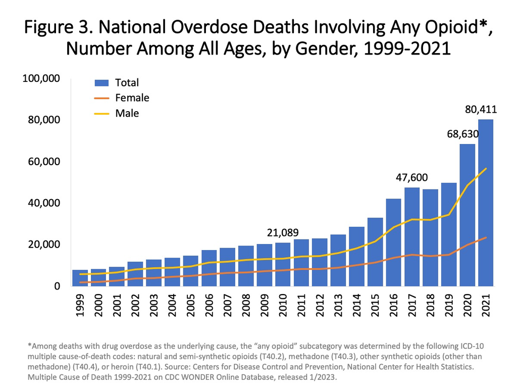

# Exploratory Modeling

Following the above data exploration, we have determined the following:

- While VDH ED visits data extend through 2023, we do not have reliable CDC WONDER overdose deaths data up to that point; as such, we will use data from both sources through their shared available (and reliable) ranges: from 2015 through 2021.
- Additionally, we likely want to only include counties with appropriate data availability within our desired ranges. As of now, our inclusion/exclusion criteria are TBD.

Below, we take steps needed to combine our data sources for opioid overdose ED visits and opioid overdose deaths, restricting to our aforementioned shared available (and reliable) ranges. We additionally combine these data with our Virginia county geography to yield our final data frame for analysis: `alldata_df`.

```r
alldata_df <- # merge edvisits and overdose deaths dataframes (and geography)
    combined_edvisits_df %>%
    filter(Locality != "VIRGINIA") %>% # remove VIRGINIA (state-aggregated) data
                                       # point from edvisits data
    full_join( # combine edvisits and deaths
            cdc_wonder_overdose_deaths_df,
            by = c("Year" = "Year", "Locality" = "County") # dplyr 1.0.8 syntax
    ) %>%
    left_join( # combine above with geography
        va_counties,
        by = c("Locality" = "NAMELSAD") # dplyr 1.0.8 syntax
    ) %>%
    filter(Year %in% 2015:2021) %>% # subset by desired years: 2015 to 2021
    mutate(
        Population = as.numeric(Population), # code Population as numeric
        Year.adj = Year - 2015 # create time-adjusted year value
    )
# additional processing: remove NAs, group data, and calculate slopes/intercepts
## opioid ED visits separately
summarized_edvisits_models <- alldata_df %>%
    group_by(Locality) %>% # group data
    filter(!all(is.na(combined))) %>% # remove county when ALL its rows are NA
    summarize( # calculate slopes/intercepts (double-check equation formulae)
        edvisits_intercept = coef(lm(combined ~ Year.adj))[[1]],
        edvisits_timecoeff = coef(lm(combined ~ Year.adj))[[2]]
        # edvisits_pop_coeff = coef(lm(combined ~ Year.adj + Population))[[3]]
    ) %>%
    right_join(va_counties, by = c("Locality" = "NAMELSAD")) # merge-back
                                                             # removed counties

## opioid overdose deaths separately
death_problem_counties <- alldata_df %>% # problem counties for opioid overdose
                                         # deaths have >5 non-NA values
    group_by(Locality) %>%
    summarize(sum_na = sum(is.na(Deaths))) %>% # how many NA in a county?
    filter(sum_na > 5) %>%
    .$Locality # print names of localities

summarized_deaths_models <- alldata_df %>%
    group_by(Locality) %>% # group data
    filter(! Locality %in% death_problem_counties) %>%
    summarize( #calculate slopes/intercepts (double-check equation formulae)
        deaths_intercept = coef(lm(Deaths ~ Year.adj))[[1]],
        deaths_timecoeff = coef(lm(Deaths ~ Year.adj))[[2]]
        # deaths_pop_coeff = coef(lm(Deaths ~ Year.adj + Population))[[3]]
    ) %>%
    right_join(va_counties, by = c("Locality" = "NAMELSAD")) # merge-back
                                                             # removed counties

# re-merge data together into alldata_summarized_df
alldata_summarized_df <- inner_join(
    summarized_edvisits_models,
    summarized_deaths_models
)
```

[output not shown]

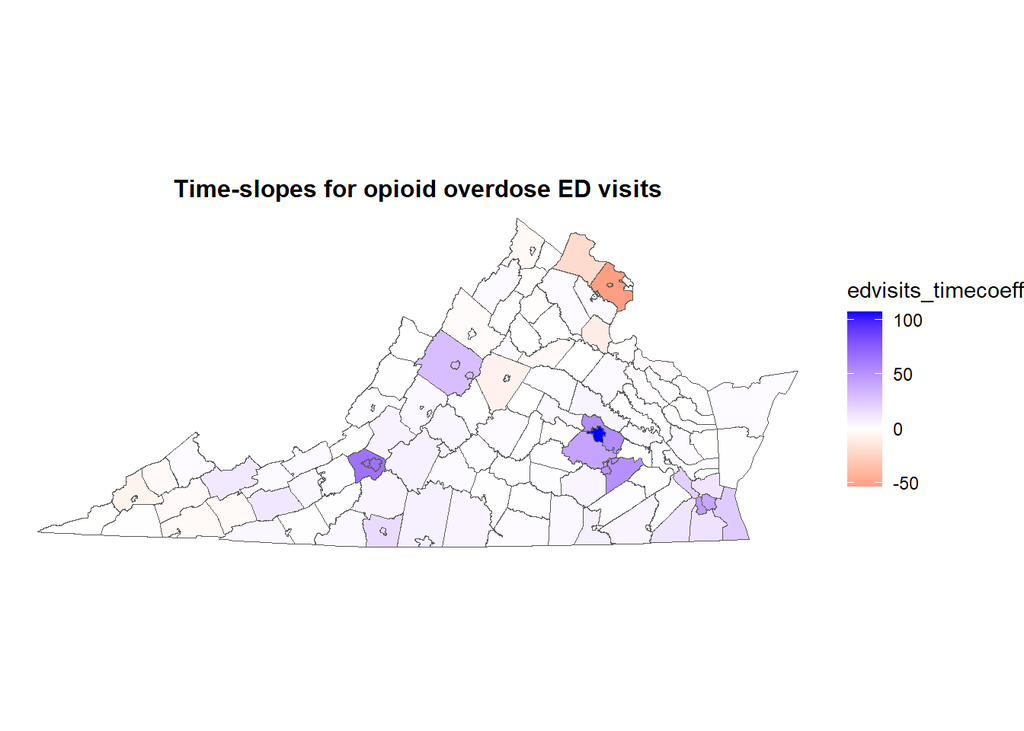

```r
# plot slopes/intercepts for edvisits data
alldata_summarized_df %>% # time-slopes
    ggplot() +
    geom_sf(aes(fill = edvisits_timecoeff, geometry = geometry)) +
    scale_fill_gradient2( # ggplot2 3.3.5 syntax
        midpoint = 0,
        high = "blue",
        mid = "white",
        low = "red",
        na.value = "black",
        guide = "colorbar"
    ) +
    theme_void() +
    ggtitle("Time-slopes for opioid overdose ED visits") +
    theme(plot.title = element_text(hjust = 0.5, size = 12, face = "bold"))
```

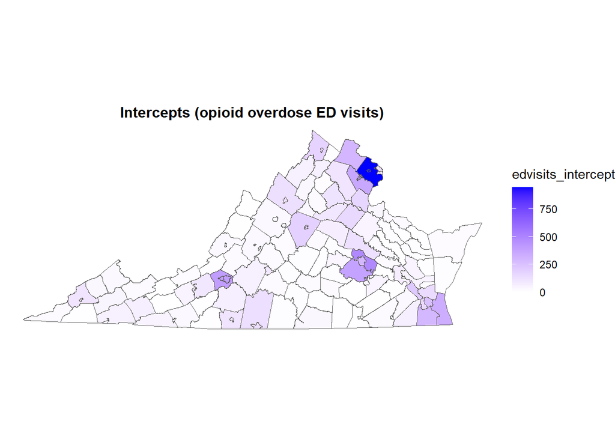

```r
# alldata_summarized_df %>% # population covariate coefficient
#     ggplot() +
#     geom_sf(aes(fill = edvisits_pop_coeff, geometry = geometry)) +
#     scale_fill_gradient2( # ggplot2 3.3.5 syntax
#         midpoint = 0,
#         high = "blue",
#         mid = "white",
#         low = "red",
#         na.value = "black",
#         guide = "colorbar"
#     ) +
#     theme_void() +
#     ggtitle("Population covariate coefficient for opioid overdose ED visits") +
#     theme(plot.title = element_text(hjust = 0.5, size = 12, face = "bold"))

alldata_summarized_df %>% # intercepts
    ggplot() +
    geom_sf(aes(fill = edvisits_intercept, geometry = geometry)) +
    scale_fill_gradient2( # ggplot2 3.3.5 syntax
        midpoint = 0,
        high = "blue",
        mid = "white",
        low = "red",
        na.value = "black",
        guide = "colorbar"
    ) +
    theme_void() +
    ggtitle("Intercepts (opioid overdose ED visits)") +
    theme(plot.title = element_text(hjust = 0.5, size = 12, face = "bold"))
```

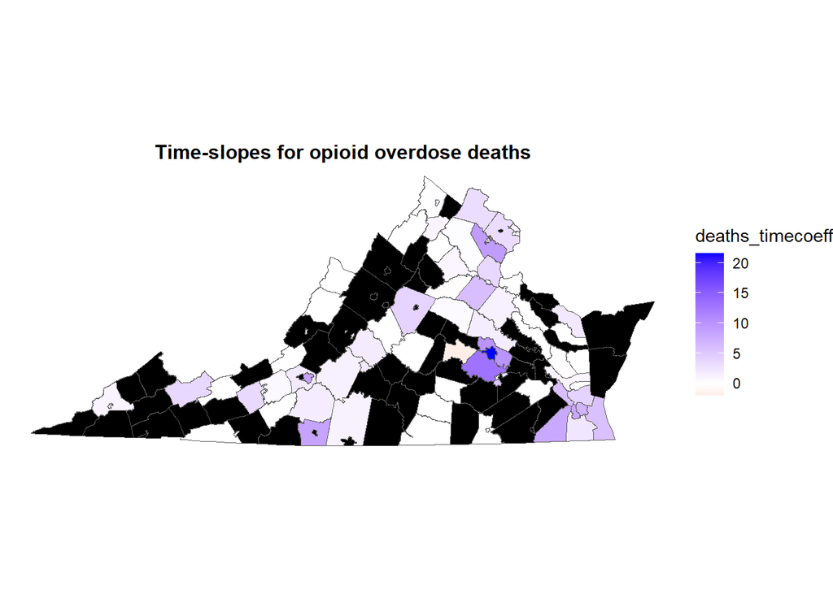

```r
# plot slopes/intercepts for deaths data
alldata_summarized_df %>% # time-slopes
    ggplot() +
    geom_sf(aes(fill = deaths_timecoeff, geometry = geometry)) +
    scale_fill_gradient2( # ggplot2 3.3.5 syntax
        midpoint = 0,
        high = "blue",
        mid = "white",
        low = "red",
        na.value = "black",
        guide = "colorbar"
    ) +
    theme_void() +
    ggtitle("Time-slopes for opioid overdose deaths") +
    theme(plot.title = element_text(hjust = 0.5, size = 12, face = "bold"))
```

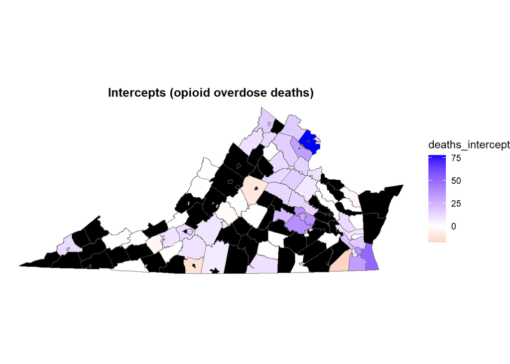

```r
# alldata_summarized_df %>% # population covariate coefficient
#     ggplot() +
#     geom_sf(aes(fill = deaths_pop_coeff, geometry = geometry)) +
#     scale_fill_gradient2( # ggplot2 3.3.5 syntax
#         midpoint = 0,
#         high = "blue",
#         mid = "white",
#         low = "red",
#         na.value = "black",
#         guide = "colorbar"
#     ) +
#     theme_void() +
#     ggtitle("Population covariate coefficient for opioid overdose deaths") +
#     theme(plot.title = element_text(hjust = 0.5, size = 12, face = "bold"))

alldata_summarized_df %>% # intercepts
    ggplot() +
    geom_sf(aes(fill = deaths_intercept, geometry = geometry)) +
    scale_fill_gradient2( # ggplot2 3.3.5 syntax
        midpoint = 0,
        high = "blue",
        mid = "white",
        low = "red",
        na.value = "black",
        guide = "colorbar"
    ) +
    theme_void() +
    ggtitle("Intercepts (opioid overdose deaths)") +
    theme(plot.title = element_text(hjust = 0.5, size = 12, face = "bold"))
```

We also print an excerpt of `alldata_summarized` below, to show all coefficients in tabular format and various values:

```r
# show NAs
alldata_summarized_df %>%
    select( # select only relevant variables for table display
        Locality,
        edvisits_intercept,
        edvisits_timecoeff,
        # edvisits_pop_coeff,
        deaths_intercept,
        deaths_timecoeff
        # deaths_pop_coeff
    ) %>%
    knitr::kable(style = "html")
```

| Locality | edvisits_intercept | edvisits_timecoeff | deaths_intercept | deaths_timecoeff |
| --- | --- | --- | --- | --- |
| ACCOMACK COUNTY | 15.2142857 | 1.7857143 | NA | NA |
| ALBEMARLE COUNTY | 186.7142857 | -7.1428571 | -10.000000 | 4.0000000 |
| ALEXANDRIA CITY | 106.8928571 | 0.0357143 | 8.139535 | 2.1279070 |
| ALLEGHANY COUNTY | 26.7500000 | 1.3214286 | NA | NA |
| AMELIA COUNTY | 12.7500000 | 1.3214286 | NA | NA |
| AMHERST COUNTY | 18.5000000 | 4.0714286 | -1.833333 | 1.8333333 |
| APPOMATTOX COUNTY | 12.4642857 | 1.4642857 | NA | NA |
| ARLINGTON COUNTY | 129.1428571 | -3.4285714 | 16.285714 | 1.0714286 |
| AUGUSTA COUNTY | 27.3571429 | 29.9285714 | NA | NA |
| BATH COUNTY | 2.6071429 | 0.3214286 | 0.000000 | 0.0000000 |
| BEDFORD COUNTY | 61.9285714 | 6.6428571 | 8.500000 | 1.2692308 |
| BLAND COUNTY | -1.7500000 | 2.3928571 | 0.000000 | 0.0000000 |
| BOTETOURT COUNTY | 22.2500000 | 5.8214286 | NA | NA |
| BRISTOL CITY | 59.7857143 | -3.3571429 | NA | NA |
| BRUNSWICK COUNTY | 9.9642857 | 2.9642857 | NA | NA |
| BUCHANAN COUNTY | 25.3928571 | 1.6785714 | NA | NA |
| BUCKINGHAM COUNTY | 12.4642857 | 1.7500000 | 0.000000 | 0.0000000 |
| BUENA VISTA CITY | 27.1428571 | 3.1428571 | 0.000000 | 0.0000000 |
| CAMPBELL COUNTY | 24.8214286 | 2.3928571 | NA | NA |
| CAROLINE COUNTY | 43.7857143 | 2.0714286 | 7.728814 | 1.3389831 |
| CARROLL COUNTY | 27.3928571 | 0.6785714 | NA | NA |
| CHARLES CITY COUNTY | 6.1785714 | -0.1071429 | NA | NA |
| CHARLOTTE COUNTY | 13.1785714 | 1.0357143 | NA | NA |
| CHARLOTTESVILLE CITY | 186.7142857 | -7.1428571 | NA | NA |
| CHESAPEAKE CITY | 292.8214286 | 13.3928571 | 32.892857 | 2.3214286 |
| CHESTERFIELD COUNTY | 380.9642857 | 42.3928571 | 37.892857 | 13.0357143 |
| CLARKE COUNTY | 13.2500000 | -0.1785714 | NA | NA |
| COLONIAL HEIGHTS CITY | 380.9642857 | 42.3928571 | 7.000000 | 0.1428571 |
| COVINGTON CITY | 26.7500000 | 1.3214286 | 0.000000 | 0.0000000 |
| CRAIG COUNTY | 6.2142857 | 0.3571429 | 0.000000 | 0.0000000 |

[output cut: 103 more lines]

```r
# exclude NAs
alldata_summarized_df %>%
    select( # select only relevant variables for table display
        Locality,
        edvisits_intercept,
        edvisits_timecoeff,
        # edvisits_pop_coeff,
        deaths_intercept,
        deaths_timecoeff
        # deaths_pop_coeff,
    ) %>%
    na.exclude() %>%
    knitr::kable(style = "html")
```

| Locality | edvisits_intercept | edvisits_timecoeff | deaths_intercept | deaths_timecoeff |
| --- | --- | --- | --- | --- |
| ALBEMARLE COUNTY | 186.7142857 | -7.1428571 | -10.000000 | 4.0000000 |
| ALEXANDRIA CITY | 106.8928571 | 0.0357143 | 8.139535 | 2.1279070 |
| AMHERST COUNTY | 18.5000000 | 4.0714286 | -1.833333 | 1.8333333 |
| ARLINGTON COUNTY | 129.1428571 | -3.4285714 | 16.285714 | 1.0714286 |
| BATH COUNTY | 2.6071429 | 0.3214286 | 0.000000 | 0.0000000 |
| BEDFORD COUNTY | 61.9285714 | 6.6428571 | 8.500000 | 1.2692308 |
| BLAND COUNTY | -1.7500000 | 2.3928571 | 0.000000 | 0.0000000 |
| BUCKINGHAM COUNTY | 12.4642857 | 1.7500000 | 0.000000 | 0.0000000 |
| BUENA VISTA CITY | 27.1428571 | 3.1428571 | 0.000000 | 0.0000000 |
| CAROLINE COUNTY | 43.7857143 | 2.0714286 | 7.728814 | 1.3389831 |
| CHESAPEAKE CITY | 292.8214286 | 13.3928571 | 32.892857 | 2.3214286 |
| CHESTERFIELD COUNTY | 380.9642857 | 42.3928571 | 37.892857 | 13.0357143 |
| COLONIAL HEIGHTS CITY | 380.9642857 | 42.3928571 | 7.000000 | 0.1428571 |
| COVINGTON CITY | 26.7500000 | 1.3214286 | 0.000000 | 0.0000000 |
| CRAIG COUNTY | 6.2142857 | 0.3571429 | 0.000000 | 0.0000000 |
| CULPEPER COUNTY | 109.1071429 | -0.1785714 | 12.607143 | 0.8928571 |
| EMPORIA CITY | 8.8214286 | 7.1071429 | 0.000000 | 0.0000000 |
| ESSEX COUNTY | 13.3214286 | -0.9642857 | 0.000000 | 0.0000000 |
| FAIRFAX COUNTY | 947.9642857 | -53.4642857 | 77.785714 | 3.2142857 |
| FALLS CHURCH CITY | 947.9642857 | -53.4642857 | -1.879518 | 1.3012048 |
| FAUQUIER COUNTY | 106.8214286 | 1.6785714 | 16.071429 | 0.2857143 |
| FLOYD COUNTY | 8.0357143 | 1.0357143 | 0.000000 | 0.0000000 |
| FRANKLIN COUNTY | 65.3928571 | 4.8214286 | 9.271186 | 1.6610169 |
| FREDERICK COUNTY | 175.6785714 | -4.1785714 | 16.785714 | 0.2142857 |
| FREDERICKSBURG CITY | 49.7142857 | -2.1428571 | 8.000000 | 1.2142857 |
| GALAX CITY | 46.3214286 | 3.6071429 | 0.000000 | 0.0000000 |
| GLOUCESTER COUNTY | 42.9285714 | 2.0714286 | 12.200000 | -0.2000000 |
| GRAYSON COUNTY | 46.3214286 | 3.6071429 | 0.000000 | 0.0000000 |
| GREENSVILLE COUNTY | 8.8214286 | 7.1071429 | 0.000000 | 0.0000000 |
| HAMPTON CITY | 140.8928571 | 12.1785714 | 17.607143 | 4.0357143 |
| HANOVER COUNTY | 119.6785714 | 4.5357143 | 14.857143 | 1.7428571 |
| HENRICO COUNTY | 483.2142857 | 53.5000000 | 36.642857 | 9.9285714 |
| HENRY COUNTY | 108.5357143 | 16.6785714 | -12.200000 | 8.5000000 |
| HIGHLAND COUNTY | 0.2142857 | 0.0714286 | 0.000000 | 0.0000000 |
| HOPEWELL CITY | 45.6428571 | 51.3571429 | 5.650000 | 2.4000000 |
| KING AND QUEEN COUNTY | 5.5000000 | 1.3571429 | 0.000000 | 0.0000000 |
| KING GEORGE COUNTY | 32.2857143 | -1.1428571 | 10.000000 | 0.0000000 |
| LANCASTER COUNTY | 12.0357143 | -0.2500000 | 0.000000 | 0.0000000 |
| LEXINGTON CITY | 27.1428571 | 3.1428571 | 0.000000 | 0.0000000 |
| LOUDOUN COUNTY | 295.3928571 | -20.4642857 | 17.392857 | 3.1071429 |
| LOUISA COUNTY | 66.2142857 | 1.3571429 | 13.000000 | 0.5000000 |
| LUNENBURG COUNTY | 7.7857143 | 0.7857143 | 0.000000 | 0.0000000 |
| LYNCHBURG CITY | 91.5000000 | 4.9285714 | 7.666667 | 2.0000000 |
| MANASSAS CITY | 357.9642857 | 2.8214286 | -6.000000 | 4.0000000 |
| MANASSAS PARK CITY | 357.9642857 | 2.8214286 | 0.000000 | 0.0000000 |
| MATHEWS COUNTY | 7.9285714 | -0.2142857 | 0.000000 | 0.0000000 |
| MECKLENBURG COUNTY | 30.6785714 | 1.8214286 | 10.000000 | 0.0000000 |
| MONTGOMERY COUNTY | 97.1071429 | 1.3928571 | 9.200000 | 0.6000000 |
| NELSON COUNTY | 14.6785714 | 0.9642857 | 0.000000 | 0.0000000 |
| NEWPORT NEWS CITY | 215.2142857 | 21.6428571 | 19.750000 | 5.8928571 |
| NORFOLK CITY | 253.4285714 | 40.5714286 | 36.428571 | 7.0000000 |
| NORTHUMBERLAND COUNTY | 8.8571429 | 0.1428571 | -3.684210 | 2.1052632 |
| NORTON CITY | 108.3571429 | -6.9285714 | 0.000000 | 0.0000000 |
| NOTTOWAY COUNTY | 19.2500000 | 1.3928571 | 0.000000 | 0.0000000 |
| ORANGE COUNTY | 96.2142857 | -2.7857143 | 13.324324 | -0.2432432 |
| PETERSBURG CITY | 45.6428571 | 51.3571429 | 2.279070 | 5.2558140 |
| PITTSYLVANIA COUNTY | 127.1785714 | 6.1785714 | 7.000000 | 1.2142857 |
| POQUOSON CITY | 15.8571429 | 0.0000000 | 0.000000 | 0.0000000 |
| PORTSMOUTH CITY | 152.9285714 | 46.2142857 | 9.607143 | 8.1785714 |
| POWHATAN COUNTY | 38.7500000 | -1.2500000 | 23.000000 | -2.0000000 |
| PRINCE WILLIAM COUNTY | 357.9642857 | 2.8214286 | 31.928571 | 9.2142857 |
| PULASKI COUNTY | 46.3571429 | 3.6428571 | -4.000000 | 3.5000000 |
| RADFORD CITY | 97.1071429 | 1.3928571 | 0.000000 | 0.0000000 |
| RAPPAHANNOCK COUNTY | 10.3928571 | -1.6071429 | 0.000000 | 0.0000000 |
| RICHMOND CITY | 292.1071429 | 107.3928571 | 29.142857 | 21.5714286 |
| ROANOKE CITY | 401.5357143 | 65.3928571 | 14.250000 | 8.5357143 |
| ROANOKE COUNTY | 401.5357143 | 65.3928571 | 11.800000 | 1.9142857 |
| SHENANDOAH COUNTY | 61.0714286 | 2.0714286 | 10.000000 | 0.0000000 |
| SPOTSYLVANIA COUNTY | 151.8214286 | 0.1071429 | 16.428571 | 6.0000000 |
| STAFFORD COUNTY | 167.0000000 | -10.4285714 | 14.607143 | 3.6071429 |
| SUFFOLK CITY | 64.2857143 | 11.8571429 | -17.666667 | 8.0000000 |
| SURRY COUNTY | 3.0714286 | 0.6428571 | 0.000000 | 0.0000000 |
| TAZEWELL COUNTY | 20.5714286 | 10.2857143 | 1.085714 | 3.6857143 |
| VIRGINIA BEACH CITY | 334.5357143 | 23.6785714 | 51.071429 | 5.7857143 |
| WARREN COUNTY | 61.0357143 | -0.8214286 | 12.642857 | 1.0571429 |
| WINCHESTER CITY | 175.6785714 | -4.1785714 | 9.384615 | 0.8846154 |
| WISE COUNTY | 108.3571429 | -6.9285714 | 11.452381 | 1.0714286 |
| YORK COUNTY | 48.8928571 | 1.6071429 | 9.000000 | 1.0000000 |

Below are the CDC WONDER opioid overdose deaths timeseries values for states that returned NA slopes from the opioid overdose deaths regressions:

| County | 2015 | 2016 | 2017 | 2018 | 2019 | 2020 | 2021 |
| --- | --- | --- | --- | --- | --- | --- | --- |
| ACCOMACK COUNTY | NA | NA | NA | NA | NA | NA | NA |
| ALLEGHANY COUNTY | NA | NA | NA | NA | NA | NA | NA |
| AMELIA COUNTY | NA | NA | NA | NA | NA | NA | NA |
| APPOMATTOX COUNTY | NA | NA | 0 | NA | NA | NA | NA |
| AUGUSTA COUNTY | NA | NA | 12 | NA | NA | NA | NA |
| BOTETOURT COUNTY | NA | NA | NA | NA | NA | NA | 10 |
| BRUNSWICK COUNTY | NA | NA | NA | NA | NA | NA | NA |
| BUCHANAN COUNTY | NA | NA | NA | NA | NA | NA | NA |
| CAMPBELL COUNTY | NA | NA | NA | NA | NA | 11 | NA |
| CARROLL COUNTY | NA | NA | NA | NA | NA | NA | NA |
| CHARLES CITY COUNTY | NA | NA | NA | NA | NA | 0 | NA |
| CHARLOTTE COUNTY | 0 | NA | NA | NA | NA | NA | NA |
| CLARKE COUNTY | NA | NA | NA | NA | NA | 0 | NA |
| CUMBERLAND COUNTY | NA | NA | NA | 0 | NA | NA | NA |
| DICKENSON COUNTY | NA | NA | NA | NA | NA | NA | NA |
| DINWIDDIE COUNTY | NA | 0 | NA | NA | NA | NA | NA |
| FLUVANNA COUNTY | NA | NA | NA | NA | NA | NA | NA |
| GILES COUNTY | NA | NA | NA | 0 | NA | NA | NA |
| GOOCHLAND COUNTY | NA | NA | NA | 0 | NA | NA | NA |
| GREENE COUNTY | NA | 0 | NA | NA | NA | NA | NA |
| HALIFAX COUNTY | NA | NA | NA | NA | NA | NA | 15 |
| ISLE OF WIGHT COUNTY | NA | NA | NA | NA | NA | NA | NA |
| JAMES CITY COUNTY | NA | NA | NA | NA | NA | 15 | NA |
| KING WILLIAM COUNTY | NA | NA | NA | NA | NA | NA | 10 |
| LEE COUNTY | NA | NA | NA | NA | NA | NA | NA |
| MADISON COUNTY | NA | NA | NA | NA | NA | NA | NA |
| MIDDLESEX COUNTY | NA | NA | NA | 0 | NA | NA | NA |
| NEW KENT COUNTY | NA | 0 | NA | NA | NA | NA | NA |
| NORTHAMPTON COUNTY | 0 | NA | NA | NA | NA | NA | NA |
| PAGE COUNTY | NA | NA | NA | NA | NA | NA | NA |
| PATRICK COUNTY | NA | NA | 0 | NA | NA | NA | NA |
| PRINCE EDWARD COUNTY | NA | NA | NA | NA | NA | NA | NA |
| PRINCE GEORGE COUNTY | NA | NA | NA | NA | NA | NA | 12 |
| RICHMOND COUNTY | NA | 0 | NA | NA | NA | NA | NA |
| ROCKBRIDGE COUNTY | NA | NA | NA | 0 | NA | NA | NA |
| ROCKINGHAM COUNTY | NA | NA | NA | NA | NA | 12 | NA |
| RUSSELL COUNTY | NA | NA | NA | NA | NA | NA | NA |
| SCOTT COUNTY | NA | NA | 0 | NA | NA | NA | NA |
| SMYTH COUNTY | NA | NA | NA | NA | NA | NA | NA |
| SOUTHAMPTON COUNTY | NA | NA | 0 | NA | NA | NA | NA |
| SUSSEX COUNTY | 0 | NA | NA | NA | NA | NA | NA |
| WASHINGTON COUNTY | NA | NA | NA | NA | NA | NA | 15 |
| WESTMORELAND COUNTY | NA | NA | NA | NA | NA | NA | NA |
| WYTHE COUNTY | NA | NA | NA | NA | NA | NA | NA |
| BRISTOL CITY | NA | NA | NA | NA | NA | NA | NA |
| CHARLOTTESVILLE CITY | NA | NA | NA | NA | NA | NA | 11 |
| DANVILLE CITY | NA | NA | NA | NA | NA | 10 | NA |
| FAIRFAX CITY | NA | NA | NA | NA | NA | NA | NA |
| FRANKLIN CITY | NA | 0 | NA | NA | NA | NA | NA |
| HARRISONBURG CITY | NA | NA | NA | NA | NA | NA | NA |
| MARTINSVILLE CITY | NA | NA | NA | NA | NA | NA | NA |
| SALEM CITY | NA | NA | NA | NA | NA | NA | NA |
| STAUNTON CITY | NA | NA | NA | NA | NA | NA | NA |
| WAYNESBORO CITY | NA | NA | NA | NA | NA | NA | NA |
| WILLIAMSBURG CITY | 0 | NA | NA | NA | NA | NA | NA |

# Remaining Action Items

- solve `readRDS(pfile): error reading the file` warnings (50+) issue in first chunk (without simply `warning=F` flagging the chunk)
- properly describe & reference CDC WONDER data selection: underlying causes as overdose and multiple causes to include all classes of opioid drugs
- determine & document inclusion/exclusion criteria for county-trajectories
- on a per-county basis, visualize all counties’ (meeting inclusion criteria) overdose emergency department visits and overdose deaths on the same plot (vertical axis: “cases” rather than unique individuals, etc.)
- find & visualize relevant national data on this topic
- re-download CDC WONDER data to include Virginia state-aggregated data
- visualize state-aggregated Virginia data in place of old removed CDC WONDER graphic
- calculate trajectory slopes & intercepts
- visualize missingness, trajectory slopes, and trajectory intercepts on chloropleth maps
- visualize missingness, trajectory slopes, and trajectory intercepts on table